# WGA606

Zachary Palmore

11/16/2020

## Abstract

Although efforts have been made to reduce the gender wage gap and studies suggest that people support efforts to promote pay equity, evidence of this gap, measured through the average earnings of males and females, show that there has been little change since 2004. However, some studies point towards an increasing average annual salary for women during this time and attribute the cause to factors such as education. For this analysis we observe for those aged twenty-five and older, if the level of education attained has an effect on the average annual earnings of males and females across the United States in 2018. We extend this analysis further to determine if there is a difference at the state level in wages and discover where, if any, state has significantly reduced their gender wage gap in 2018. Preliminary results suggest that higher education does assist women in increasing their average annual earnings but it does not reduce the gender wage gap.

## Data

A copy of the data used in this survey was made available in the public Github repository listed below with the reference by the author. It was made available as a csv file and can be read remotely from any connected device to improve the reproducibility of this work.

In this analysis, the survey data is called directly from the remotely accessible repository and used throughout. Subsets of the spreadsheet are broken out into smaller tables and data frames for use in the analysis. We begin with the essentials of state identifiers, median earnings for the population of working age (16), and median earnings for educational attainment. Each is broken down by the traditional male or female gender for comparison.

```r
# Load Data
income_2018_bystate  <-  read_csv("https://raw.githubusercontent.com/palmorezm/msdsdata606/master/Project/ACSST5Y2018.S2001.csv")
# Select relevant income-specific variables by state
earnings <- income_2018_bystate[2:53,1:242] %>%
  select(c(
    # General Identifier
        NAME, # State Name

    # Population and overall earnings
    S2001_C03_002E, # Male median earnings 16+
    S2001_C05_002E, # Female median earnings 16+
    S2001_C03_013E, # Male full-time median earnings
    S2001_C05_013E, # Female full-time median earnings
    S2001_C03_015E, # Male median earnings 25+
    S2001_C05_015E, # Female median earnings 25+

    # Male earnings by education
    S2001_C03_016E, # Less than high school diploma
    S2001_C03_017E, # High school diploma
    S2001_C03_018E, # Some college or associates degree
    S2001_C03_019E, # Bachelors degree
    S2001_C03_020E, # Masters Degree


    # Female earnings by education
    S2001_C05_016E, # Less than high school diploma
    S2001_C05_017E, # High school diploma
    S2001_C05_018E, # Some college or associates degree
    S2001_C05_019E, # Bachelors degree
    S2001_C05_020E # Masters Degree

  )) %>%
  rename(
    State = NAME,
    m16 = S2001_C03_002E,
    f16 = S2001_C05_002E,
    mft = S2001_C03_013E,
    fft = S2001_C05_013E,
    m25 = S2001_C03_015E,
    f25 = S2001_C05_015E,
    flt = S2001_C05_016E,
    fhs = S2001_C05_017E,
    fas = S2001_C05_018E,
    fbs = S2001_C05_019E,
    fms = S2001_C05_020E,
    mlt = S2001_C03_016E,
    mhs = S2001_C03_017E,
    mas = S2001_C03_018E,
    mbs = S2001_C03_019E,
    mms = S2001_C03_020E
  )
# Convert numeric data to useful types
earnings[,2:17] <- lapply(earnings[,2:17], as.numeric)
head(earnings, 3)
```

```
## # A tibble: 3 x 17
##   State    m16   f16   mft   fft   m25   f25   mlt   mhs   mas   mbs   mms   flt
##   <chr>  <dbl> <dbl> <dbl> <dbl> <dbl> <dbl> <dbl> <dbl> <dbl> <dbl> <dbl> <dbl>
## 1 Alaba~ 36576 24640 48414 35751 42319 28713 25734 34851 41996 63785 81597 15463
## 2 Alaska 45195 31929 60481 48900 53670 37676 30014 41992 53070 69624 89173 21379
## 3 Arizo~ 35820 27484 47584 39967 41672 32074 25199 32373 41541 62953 82617 17192
## # ... with 4 more variables: fhs <dbl>, fas <dbl>, fbs <dbl>, fms <dbl>
```

From this sample of the data we notice the column variables are not descriptive, they are coded. Other than the state name, there is *m16* which represents the median values for males aged 16 and older. Similarly, *f16* represents the same for age females. The variable *mft* represents the males that work full time while *mlt*, *mhs*, *mas*, *mbs*, and *mms* each represent median earnings of the education levels of individuals with less than a high school, high school diplomas, some college or associates degrees, bachelors degrees, masters or graduate degrees respectively. The same categories apply but for females where the variable name starts with an ‘f’.

Due to longstanding practice, data representation for individuals who do not fit within traditional gender rules, is lacking. This is not to say that this analysis intends to exclude anyone from the analysis, only that the data to perform it is absent. Furthermore, including these factors would only serve to improve the results and their applicability to the real-world as there is a proportion of the population that such data would serve better than that of typical data sets such as this one.

In addition to the earnings data extracted from the ACS survey, we will also extract some state-specific data for later use. To perform certain tests, the data will need enough cases to make inferences from. With the calculations of medians for each state already cleaned and organized we will need to reverse some of the process while maintaining the integrity of those same median calculations. Our goal here being, to supply a data set with observations of differences their gender and education, categories as well as their associated proportions. Notes are made for guidance in the process of extracting these additional variables.

```r
# Further data extraction
income_2018_bystate <- income_2018_bystate[2:52,] %>%
  select(c(
    # General Reference Variables
    GEO_ID, # Unique Geographic Identifier of state
           NAME, # State Name
                S2001_C01_001E, # Total population 16+ MOE
                              S2001_C01_001M, # Total population 16+

    # Mean Earnings for FULL-TIME Workers (age 16+)
           S2001_C03_002E,
           S2001_C03_002M, # Median Female Earnings
           S2001_C05_002E,
           S2001_C05_002M, # Median

           # Male Variables
           S2001_C03_016E,
           S2001_C03_016M,
           S2001_C03_017E,
           S2001_C03_017M,
           S2001_C03_018E,
           S2001_C03_018M,
           S2001_C03_019E,
           S2001_C03_019M,
           S2001_C03_020E,
           S2001_C03_020M,

           # Female Variables
           S2001_C05_016E,
           S2001_C05_016M,
           S2001_C05_017E,
           S2001_C05_017M,
           S2001_C05_018E,
           S2001_C05_018M,
           S2001_C05_019E,
           S2001_C05_019M,
           S2001_C05_020E,
           S2001_C05_020M
           )) %>%
  rename(
  # Location Information
    GEO_ID = GEO_ID,
           State = NAME,

     # General Statistics on Male and Female Earnings aged 16+
          TotalPop = S2001_C01_001E,
          TotalPop_moe = S2001_C01_001M,
           M_Earnings = S2001_C03_002E, # Female
           M_Earnings_moe =  S2001_C03_002M,
           F_Earnings = S2001_C05_002E,
           F_Earnings_moe =  S2001_C05_002M,

   # Male Earnings by Level of Education (aged 25+)
         M_LTHS = S2001_C03_016E,
           M_HS = S2001_C03_017E,
           M_AS = S2001_C03_018E,
           M_BS = S2001_C03_019E,
           M_MS = S2001_C03_020E,

        # Male Margins of Error by Education
         M_LTHS_moe = S2001_C03_016M,
           M_HS_moe = S2001_C03_017M,
           M_AS_moe = S2001_C03_018M,
           M_BS_moe = S2001_C03_019M,
           M_MS_moe = S2001_C03_020M,

  # Female Earnings by Level of Education (aged 25+)
         F_LTHS = S2001_C05_016E,
           F_HS = S2001_C05_017E,
           F_AS = S2001_C05_018E,
           F_BS = S2001_C05_019E,
           F_MS = S2001_C05_020E,

        # Female Margins of Error by Education
          F_LTHS_moe = S2001_C05_016M,
           F_HS_moe = S2001_C05_017M,
           F_AS_moe = S2001_C05_018M,
           F_BS_moe = S2001_C05_019M,
           F_MS_moe = S2001_C05_020M,
         )
# Converting data types
income_2018_bystate[,3:28] <- lapply(income_2018_bystate[,3:28], as.numeric)
income_2018_bystate$GEO_ID <- as.factor(income_2018_bystate$GEO_ID)
income_2018_bystate<- as.data.frame(income_2018_bystate)

# Checking for missing values - there should be none
sum(is.na(income_2018_bystate))
```

```
## [1] 0
```

```r
# Creating subsets of the data to isolate variables of interest

# excluding geo_id and moe for summary purposes
pop_income_2018 <- income_2018_bystate[,c(2,3,5,7)]
male_income_2018 <- income_2018_bystate[, c(2,seq(9, 18, 2))]
female_income_2018 <- income_2018_bystate[, c(2,seq(19, 28, 2))]

# These male and female stats can also be recombined
mf_income_2018 <- cbind(female_income_2018, male_income_2018[2:6])

# Calculate observed differences for the entire study
pop_obs <- pop_income_2018 %>%
  mutate(Obs_diff = M_Earnings - F_Earnings) %>%
  mutate(Pmf = F_Earnings/M_Earnings)

# Create a table with the highs and lows of states
# Alternatively tail could be used:
# min(tail(sort(pop_obs$Obs_diff),5))
top5 <- pop_obs %>%
  filter(Obs_diff >= min(head(sort(pop_obs$Obs_diff, decreasing=TRUE), 5)))
top5$Gap <- as.factor("Wide")
low5 <- pop_obs %>%
  filter(Obs_diff <= max(head(sort(pop_obs$Obs_diff, decreasing=FALSE), 5)))
low5$Gap <- as.factor("Narrow")
hilo_obs <- rbind(top5,low5)

# Calculating the observed differences of sex
mf_obs <- mf_income_2018 %>%
  mutate(obs_diff_lths = M_LTHS - F_LTHS) %>%
  mutate(obs_diff_hs = M_HS - F_HS) %>%
  mutate(obs_diff_as = M_AS - F_AS) %>%
  mutate(obs_diff_bs = M_BS - F_BS) %>%
  mutate(obs_diff_ms = M_MS - F_MS)

# Give each variable its own row in education
mf_stateobs <- melt(mf_obs)
mf_stateobs[4] <- as.numeric(seq(1:51))
  mf_stateobs  <- mf_stateobs %>%
    rename(Category = variable,
           Observation = value,
           ID = V4)
mf_state_obsdiffs <- melt(mf_obs[,12:16])
  mf_state_obsdiffs <- mf_state_obsdiffs %>%
    rename(Observation = variable,
           Difference = value)
mf_earnings_byedu <- melt(mf_obs[,2:11])
# summarizing the education earning using means
mf_earnings_byedu <- mf_earnings_byedu %>%
  group_by(variable) %>%
  summarise(AvgEarning = mean(value)) %>%
  rename(Education = variable)
# Add in the variable of sex for later comparisons
mf_earnings_byedu$Sex <- c("Female","Female","Female","Female","Female","Male","Male","Male","Male","Male")
# Rename the education observations to be descriptive of
# the entire data set and remove the male/female bounds of edu
mf_earnings_byedu$Education <-
  c("LTHS","HS","AS","BS","MS","LTHS","HS","AS","BS","MS")
# Variables chosen to describe the data are not mutually exclusive
# For example 'BS' is not just for Bachelors of Science.
# That category includes all those individuals that
# attained a bachelors degree on the ACS in 2018
# and as another example 'AS' contains those with 'some college'
# from the ACS in 2018. These variables were only used for ease
# in describing the variables visually
```

This shortened table displays the first 10 statistics used in this study and the associated margins of error provided by the ACS for their calculations of the median and other relevant statistics in the year 2018. These provide a general reference to those interested in determining the exact values of the medians and other statistics used throughout this analysis. They are used to consider which estimates are the safest in this work and help to ensure quality data is used in the figures but they are for reference only and are not included in the calculations made.

```r
head(income_2018_bystate,10)
```

```
##         GEO_ID                State TotalPop TotalPop_moe M_Earnings
## 1  0400000US01              Alabama  2319177         7576      36576
## 2  0400000US02               Alaska   421213         1781      45195
## 3  0400000US04              Arizona  3396671         9044      35820
## 4  0400000US05             Arkansas  1434189         6303      33629
## 5  0400000US06           California 20152025        23699      40306
## 6  0400000US08             Colorado  3165808         6448      42051
## 7  0400000US09          Connecticut  2002828         5389      49879
## 8  0400000US10             Delaware   501672         2547      41018
## 9  0400000US11 District of Columbia   414178         2345      58864
## 10 0400000US12              Florida 10163248        19868      33644
##    M_Earnings_moe F_Earnings F_Earnings_moe M_LTHS M_LTHS_moe  M_HS M_HS_moe
## 1             283      24640            230  25734        367 34851      434
## 2             881      31929            367  30014       2036 41992      840
## 3             184      27484            210  25199        323 32373      229
```

[output cut: 29 more lines]

Our final data frames with which the majority of the analysis will be used are the *earnings* and *income_2018_bystate*. From each of these we can evaluate the median earnings of education by state but they differ in a few details.

In the *income_2018_bystate* the earnings variables are medians but include all the wage earners of the population. Therefore, it also lists the total population of each state, median earnings by gender and education by those same states, as well as the margins of error for each relevant statistic provided by the ACS. The geographic identifier of each state and the District of Columbia was also included as an option for visualizing the data further into the analysis. We extract from this basic data set the remaining subsets of the data frame that as necessary.

```r
# Here we review the data as a whole for ACS. Since all states have
# larger incomes for males we can find the proportion of a females
# income to that of a males across the states. The mean dollar amounts
# are listed in the "Obs_diff" column.
head(pop_obs[,c(1,5,6)], 5)
```

```
##        State Obs_diff       Pmf
## 1    Alabama    11936 0.6736658
## 2     Alaska    13266 0.7064720
## 3    Arizona     8336 0.7672808
## 4   Arkansas     8730 0.7404026
## 5 California    10268 0.7452488
```

The *earnings* data frame lists the minimum necessary to perform the gender wage gap analysis. A sample is provided in the table below where the first 3 states are listed with their data. The unique features of this data frame are the inclusion of Puerto Rico as a state (although it is not formally) and the different median annual earnings variables such as that of male and female full-time and earnings of those aged 25+ instead of only 16 and older.

```r
head(earnings, 3)
```

```
## # A tibble: 3 x 17
##   State    m16   f16   mft   fft   m25   f25   mlt   mhs   mas   mbs   mms   flt
##   <chr>  <dbl> <dbl> <dbl> <dbl> <dbl> <dbl> <dbl> <dbl> <dbl> <dbl> <dbl> <dbl>
## 1 Alaba~ 36576 24640 48414 35751 42319 28713 25734 34851 41996 63785 81597 15463
## 2 Alaska 45195 31929 60481 48900 53670 37676 30014 41992 53070 69624 89173 21379
## 3 Arizo~ 35820 27484 47584 39967 41672 32074 25199 32373 41541 62953 82617 17192
## # ... with 4 more variables: fhs <dbl>, fas <dbl>, fbs <dbl>, fms <dbl>
```

From the data frame we calculate multiple new variables such as the observed difference in wages by gender, the proportion of median female earnings to median male earnings in categories consistent with the literature.

## Analysis

First, we determine the presence or absence of a difference in the entire sample from the ACS. This provides a baseline set of information to build upon. We can then compute the observed differences between males and females average earnings in each state to examine the patterns among the states. With that, we can show the presence of a difference in earnings of male and female Americans in 2018 that has been observed in plethora of peer-reviewed studies.

As mentioned, there are several ways to approach this. We have the median annual earnings from those who are 16 years of age and older, 25 years and older, and those who are considered full-time workers with any income within the year. Since the literature often cites full-time workers earnings weekly or annually, we will follow their example.

```r
pfm.ft <- earnings %>%
  summarise(Pfm_ft = mean(fft)/mean(mft))
pfm.ft <- round(pfm.ft, digits = 4)
pfm.ft
```

```
## # A tibble: 1 x 1
##   Pfm_ft
##    <dbl>
## 1  0.797
```

The proportion of the median wages of full-time female earners to full-time male earners in 2018 is 0.7966. Importantly, this statistic is considered *raw* by the standards of the literature due to its unadjusted features in the calculation. All variables that may influence the calculation of this proportion are included, regardless of consideration to the applicability of the statistic to the terms “equal pay for equal work”. In this analysis, unequal worker pay and majority-gender occupations and industries are considered because it is necessary to understand the scope of differences between men and women in this study.

Differences in the median earnings of each gender category are were calculated alongside the proportions of females and males. The proportion is found by observing how the female median earnings compare to the male median earnings. This is because the median male earnings were always larger than the median female earnings for the categories. The only exception to this rule is in Puerto Rico where the median earnings of women who work full time is slightly higher than median male earnings by 2.5540776 percent.

```r
earnings <- earnings %>%
  mutate(dif.ft = mft - fft) %>%
  mutate(dif.16 = m16 - f16) %>%
  mutate(dif.25 = m25 - f25) %>%
  mutate(Pft = fft/mft) %>%
  mutate(P16 = f16/m16) %>%
  mutate(P25 = f25/m25)
max.pft <- summary(earnings$Pft)[6]
```

Given the other factors that are part of this exception, we will omit Puerto Rico from this analysis of the states. If the statehood status were to change and these values were to be included into the results, the data would shift towards a less realistic expectation of the experiences of individuals across the 50 states and District of Columbia. Summary statistics for each of the categories common to the states are displayed alongside with Puerto Rico separately.

```r
earnings[which.max(earnings$Pft),]
```

```
## # A tibble: 1 x 23
##   State    m16   f16   mft   fft   m25   f25   mlt   mhs   mas   mbs   mms   flt
##   <chr>  <dbl> <dbl> <dbl> <dbl> <dbl> <dbl> <dbl> <dbl> <dbl> <dbl> <dbl> <dbl>
## 1 Puert~ 17136 17431 23531 24132 18528 18971 11534 15728 19033 30079 44335  9416
## # ... with 10 more variables: fhs <dbl>, fas <dbl>, fbs <dbl>, fms <dbl>,
## #   dif.ft <dbl>, dif.16 <dbl>, dif.25 <dbl>, Pft <dbl>, P16 <dbl>, P25 <dbl>
```

```r
earnings <- earnings[1:51,]
earnings.summary <- summary(earnings[2:7])
education.summary <- summary(earnings[8:17])
earnings.summary
```

```
##       m16             f16             mft             fft
##  Min.   :32127   Min.   :21540   Min.   :42245   Min.   :32928
##  1st Qu.:36568   1st Qu.:25635   1st Qu.:47436   1st Qu.:37067
##  Median :39570   Median :26936   Median :51477   Median :39967
##  Mean   :40216   Mean   :28430   Mean   :52437   Mean   :41668
##  3rd Qu.:42424   3rd Qu.:30777   3rd Qu.:55145   3rd Qu.:45570
##  Max.   :58864   Max.   :49455   Max.   :77498   Max.   :67692
##       m25             f25
##  Min.   :38295   Min.   :26111
##  1st Qu.:41821   1st Qu.:30202
##  Median :45873   Median :31575
##  Mean   :46761   Mean   :33226
##  3rd Qu.:50472   3rd Qu.:36033
##  Max.   :67715   Max.   :57420
```

```r
earnings[,c(1,18:23)]
```

```
## # A tibble: 51 x 7
##    State                dif.ft dif.16 dif.25   Pft   P16   P25
##    <chr>                 <dbl>  <dbl>  <dbl> <dbl> <dbl> <dbl>
##  1 Alabama               12663  11936  13606 0.738 0.674 0.678
##  2 Alaska                11581  13266  15994 0.809 0.706 0.702
##  3 Arizona                7617   8336   9598 0.840 0.767 0.770
##  4 Arkansas               7894   8730  10798 0.813 0.740 0.724
##  5 California             6554  10268  11711 0.879 0.745 0.750
##  6 Colorado               9419  11259  14177 0.827 0.732 0.717
##  7 Connecticut           11848  15603  16583 0.819 0.687 0.712
##  8 Delaware               8081   9679  10704 0.849 0.764 0.774
##  9 District of Columbia   9806   9409  10295 0.873 0.840 0.848
## 10 Florida                6032   6916   7952 0.861 0.794 0.792
## # ... with 41 more rows
```

Observations made here display a trend of decreasing proportions of median female to male earnings as we change the variables from those with full-time employment to those who may not be employed full time. Between the ages of 16 and 25, the likelihood of being employed full-time is lower than for those who are 25 and older. However, there appears to be enough individuals not employed full-time in the 25 and up age group to cause the proportion of 25 and older to drop lower than for the category of full-time wage earners. We could speculate on a number of factors that could cause this but for now, we should only recognize this trend as it pertains the analysis of education across the gender wage gap.

The same process is used when computing the observed differences, proportions, and mean of proportions in the median earnings of educational attainment of individuals in this study. We organize the categories using abbreviations of science degrees for simplicity in visualizing. They are in no way exclusive and do not fully capture the depth of the data collected by the ACS. The ACS includes all educational attainment in the categories of *less than high school diploma*, *high school diploma*, *some college or an associates degree*, *bachelors degree*, and *graduate or professional degree*. We abbreviate these as LTHS, HS, AS, BS, and MS respectively.

```r
male_earnings_byedu <- mf_earnings_byedu %>%
  filter(Sex == "Male")
female_earnings_byedu <- mf_earnings_byedu %>%
  filter(Sex == "Female")
mf_earn_ed <- cbind(male_earnings_byedu, female_earnings_byedu)
mf_earn_ed <- mf_earn_ed[-4] %>%
  rename(Median_M = AvgEarning,
         Median_F = AvgEarning.1,
         Sex.M = Sex,
         Sex.F = Sex.1) %>%
  mutate(Pfm = Median_F / Median_M) %>%
  mutate(obs_dif = Median_M - Median_F) %>%
  mutate(Mean_Pfm = mean(Pfm))
mf_earn_ed
```

```
##   Education Median_M Sex.M Median_F  Sex.F       Pfm  obs_dif  Mean_Pfm
## 1      LTHS 28299.22  Male 17934.33 Female 0.6337396 10364.88 0.6723679
## 2        HS 37024.82  Male 24472.02 Female 0.6609625 12552.80 0.6723679
## 3        AS 44565.33  Male 30131.22 Female 0.6761133 14434.12 0.6723679
## 4        BS 63340.41  Male 43538.06 Female 0.6873662 19802.35 0.6723679
## 5        MS 83168.78  Male 58522.35 Female 0.7036577 24646.43 0.6723679
```

Another pattern in this data show that as education attainment level increases, so too does the observed difference in dollars. That is, as the earnings of both genders increase with higher levels of education, the dollar amount of earnings that a male earns starts and increases at a greater rate than females. We can also visualize this in few ways.

This chart displays how a higher levels of education attainment results in higher median earnings. In this case, the earned wages are displayed as weekly earnings starting with zero and extending to nearly $1,500.00 for the higher educational attainment category listed in this analysis, the master’s degree. Importantly, this data takes the mean of the median average earnings to calculate its weekly earnings, making it slightly different than the commonly discrete median or mean selected in literature.

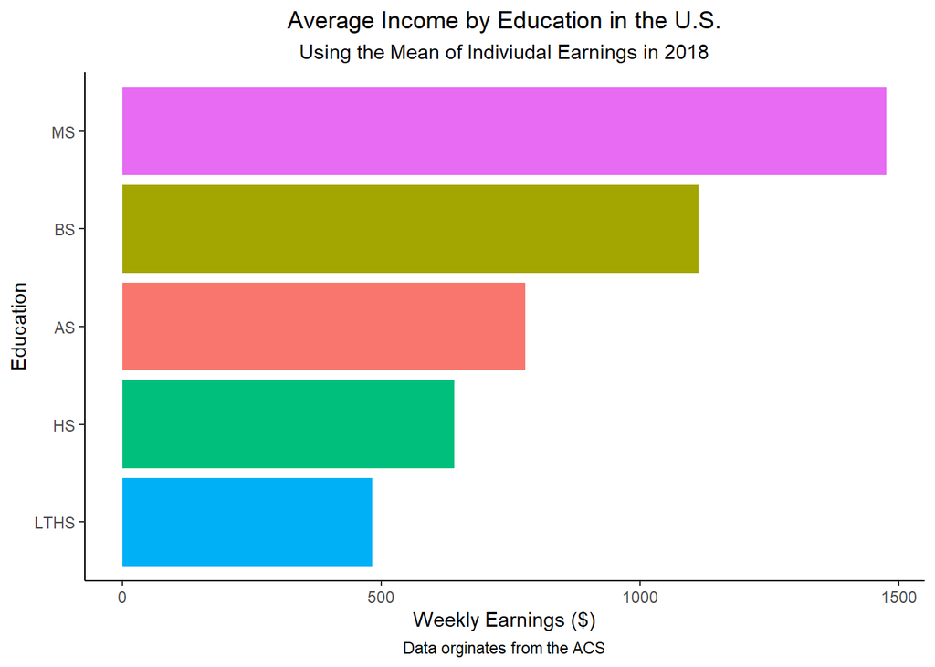

```r
mf_earnings_byedu %>%
  group_by(Education) %>%
  mutate(Mean_Earnings = mean(AvgEarning)) %>%
  filter(Sex == "Male") %>%
  mutate(AvgEarn_wkdollars = Mean_Earnings / 48) %>%
  ggplot( aes(x = reorder(Education, AvgEarn_wkdollars), y = AvgEarn_wkdollars)) +
  geom_col(aes(fill = Education)) +
  labs(x = "Education",
       y = "Weekly Earnings ($)",
       title = "Average Income by Education in the U.S.",
       subtitle = "Using the Mean of Indiviudal Earnings in 2018",
       caption = "Data orginates from the ACS") +
  theme_classic() +
  coord_flip() +
  theme(legend.position = "none",
        plot.caption = element_text(hjust = 0.5),
        plot.title = element_text(hjust = 0.5),
        plot.subtitle = element_text(hjust = 0.5))
```

Information from the chart can also be displayed as annual earnings. To make things easier, that conversion has already been completed in the following chart. Note that these annul earnings also use the mean of the median. Results will vary slightly from commonly accepted values.

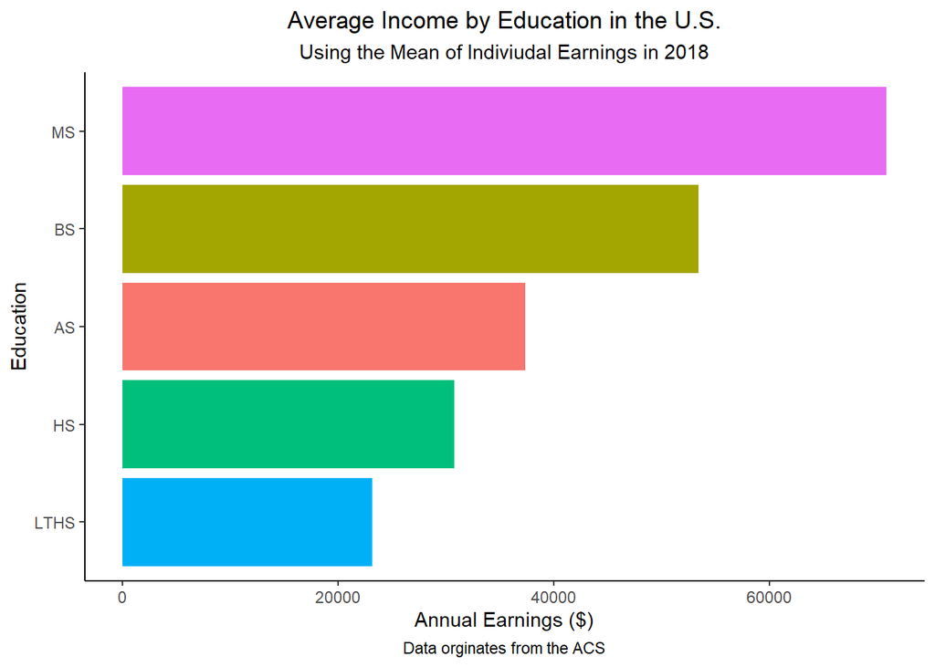

```r
mf_earnings_byedu %>%
  group_by(Education) %>%
  mutate(Mean_Earnings = mean(AvgEarning)) %>%
  filter(Sex == "Male") %>%
  ggplot( aes(x = reorder(Education, Mean_Earnings), y = Mean_Earnings)) +
  geom_col(aes(fill = Education)) +
  labs(x = "Education",
       y = "Annual Earnings ($)",
       title = "Average Income by Education in the U.S.",
       subtitle = "Using the Mean of Indiviudal Earnings in 2018",
       caption = "Data orginates from the ACS") +
  theme_classic() +
  coord_flip() +
  theme(legend.position = "none",
        plot.caption = element_text(hjust = 0.5),
        plot.title = element_text(hjust = 0.5),
        plot.subtitle = element_text(hjust = 0.5))
```

Another useful comparison of the median earnings of gender by each level of educational attainment is through this column chart. The same categories are used for the levels of education and median male and female annual earnings are reported for all individuals with any earnings in 2018.

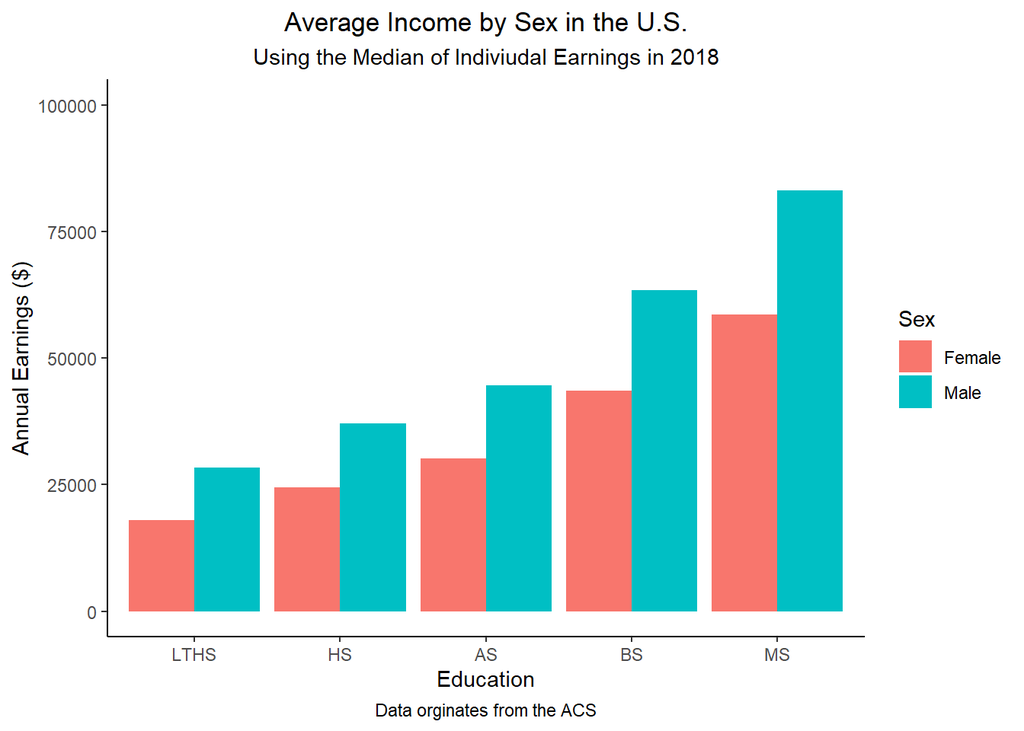

```r
ggplot(mf_earnings_byedu, aes(x = reorder(Education, AvgEarning), y = AvgEarning, fill = Sex)) +
  geom_col(position = "dodge") +
  ylim(0,100000) +
  labs(x = "Education",
       y = "Annual Earnings ($)",
       title = "Average Income by Sex in the U.S.",
       subtitle = "Using the Median of Indiviudal Earnings in 2018",
       caption = "Data orginates from the ACS") +
  theme_classic() +
  theme(plot.caption = element_text(hjust = 0.5),
        plot.title = element_text(hjust = 0.5),
        plot.subtitle = element_text(hjust = 0.5))
```

From this column chart we observe that in every mean of every education type, the male earnings bar in blue is taller than the bars of female earnings in red. Since each bar represents the median annual earnings of the individuals in each category of education, this visually displays how the annual earnings of females does not meet the median male earnings at any education level. Although, the median earning of females do increase with higher levels of education. A boxplot adds some detail to this.

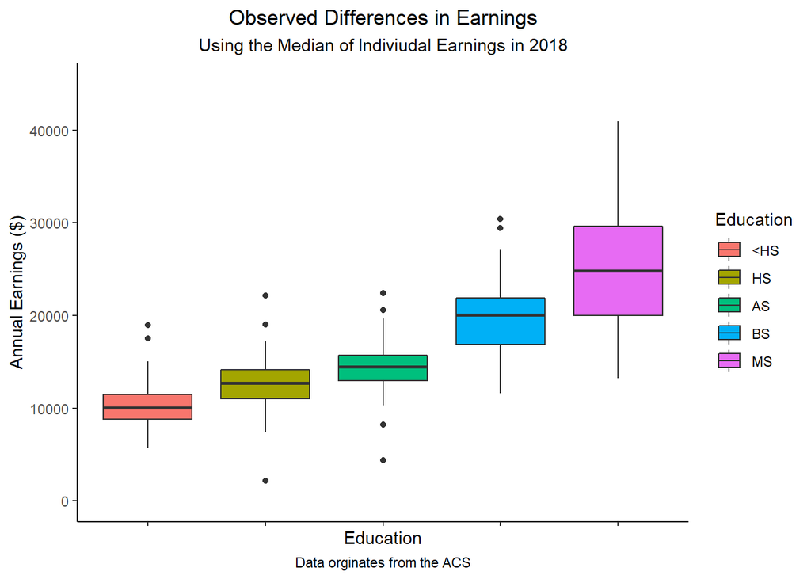

```r
ggplot(mf_state_obsdiffs, aes(x = reorder(Observation,Difference), y = Difference)) + geom_boxplot(aes(fill = Observation)) +
  ylim(0,45000) +
  scale_fill_discrete(name = "Education", labels = c("<HS", "HS", "AS", "BS", "MS")) +
  labs(x = "Education",
       y = "Annual Earnings ($)",
       title = "Observed Differences in Earnings",
       subtitle = "Using the Median of Indiviudal Earnings in 2018",
       caption = "Data orginates from the ACS") +
  theme_classic() +
  theme(axis.text.x = element_blank(),
        plot.caption = element_text(hjust = 0.5),
        plot.title = element_text(hjust = 0.5),
        plot.subtitle = element_text(hjust = 0.5))
```

To break the information into localized segments, the differences in individual earnings by state can be shown in the following chart. Only the states with the highest 5 and lowest 5 differences in earnings were selected for clarity. The states with the highest differences can be thought of as having a wider earnings gap. The reverse applies for the lowest where their earnings gap can be thought of as narrower relative to the rest of the states.

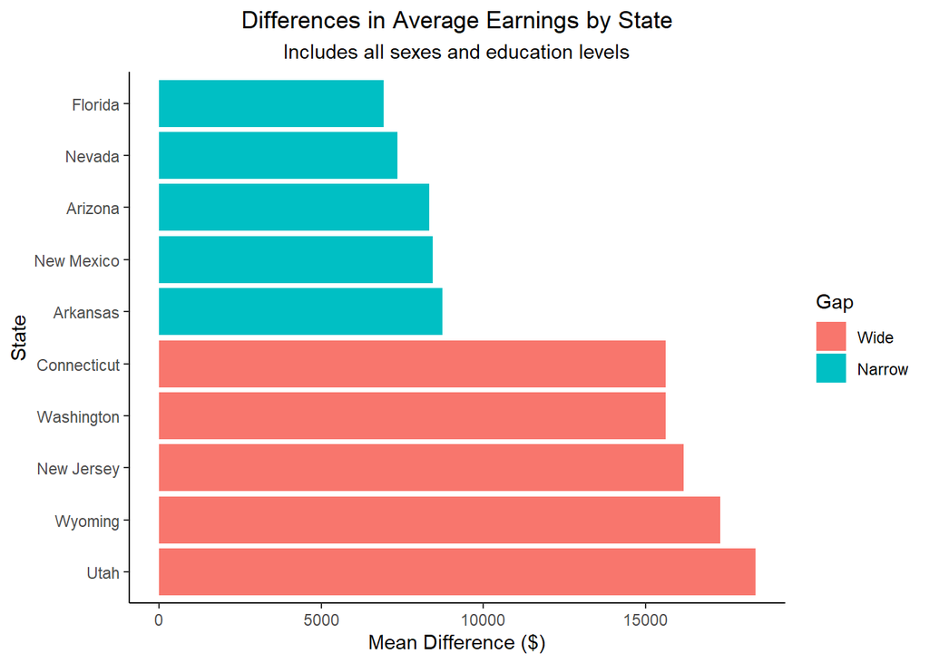

```r
ggplot(hilo_obs, aes(x = reorder(State, -Obs_diff), y = Obs_diff)) +
  labs(x = "State",
       y = "Mean Difference ($)",
       title = "Differences in Average Earnings by State",
       subtitle = "Includes all sexes and education levels") +
  geom_col(aes(fill=Gap)) +
  coord_flip() +
  theme_classic() +
  theme(plot.caption = element_text(hjust = 0.5),
        plot.title = element_text(hjust = 0.5),
        plot.subtitle = element_text(hjust = 0.5))
```

With the observational differences computed and the types of gap labeled based on the average median (or the median of the medians) we can see that there is not as much of change between those states with a wide gap and other states with wide gaps. The range of these wide gap states is $2,766 with a maximum observed difference of $18,369 and a minimum of $15,603. They have a mean proportion of female to male annual earnings of 0.6354.

In contrast, the difference between the gender wage gaps of narrow an wide states is greater than the range of the wide or narrow gaped states when compared within groups. The range of all 10 selected states is $11,453 with a maximum observed difference of $18,369 and minimum of $6,916. This represents the full range of all states since the data frame includes the highest and lowest observational values of each state’s gender gap type. A full table of these select states is shown below.

```r
hilo_obs
```

```
##          State TotalPop M_Earnings F_Earnings Obs_diff       Pmf    Gap
## 1  Connecticut  2002828      49879      34276    15603 0.6871830   Wide
## 2   New Jersey  4789487      50812      34640    16172 0.6817287   Wide
## 3         Utah  1599204      40607      22238    18369 0.5476396   Wide
## 4   Washington  3949923      46280      30663    15617 0.6625540   Wide
## 5      Wyoming   328719      43024      25726    17298 0.5979453   Wide
## 6      Arizona  3396671      35820      27484     8336 0.7672808 Narrow
## 7     Arkansas  1434189      33629      24899     8730 0.7404026 Narrow
## 8      Florida 10163248      33644      26728     6916 0.7944359 Narrow
## 9       Nevada  1513020      36560      29219     7341 0.7992068 Narrow
## 10  New Mexico   994984      32127      23683     8444 0.7371681 Narrow
```

Notice that the proportion of earnings is not always higher when the observed difference in earnings is high. The same applies to states where the observed difference in earnings is low, the resultant proportion is not always lower.

This could be due to random variation or the unique span of ranges between male and female populations of each state. Regardless, it seems to suggest that the observed difference is dollars between median male and female earning is not always an exact indicator of the gender wage gap. Given that the gender wage gap is measured by the difference in the median earnings between males and females, such a phenomenon presents a challenge in determining the significance of gender wage gaps by state.

Take another look at the gender wage gap by type. Keep in mind that both boxes represent a difference in the gender wages with their only differences stemming from their distribution and magnitude.

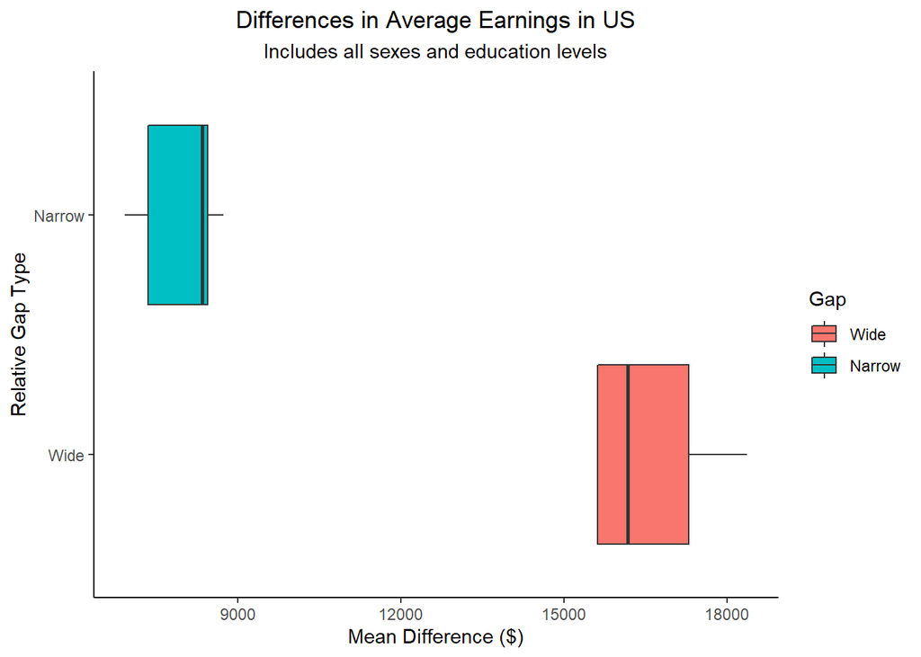

```r
ggplot(hilo_obs, aes(x = Gap, y = Obs_diff, fill = Gap)) +

  labs(x = "Relative Gap Type",
       y = "Mean Difference ($)",
       title = "Differences in Average Earnings in US",
       subtitle = "Includes all sexes and education levels") +

  geom_boxplot() +
  theme_classic() +
  theme(plot.caption = element_text(hjust = 0.5),
        plot.title = element_text(hjust = 0.5),
        plot.subtitle = element_text(hjust = 0.5)) +
  coord_flip()
```

Aside from the large gap between these two boxes, observe their distributions. States that contain relatively narrow gaps also seem to be more tightly distributed with a median located at high observational differences within in its interquartile range. On the bottom side in red, we see how wider gender wage gaps at the state level result in a looser distribution with greater upper range, little to no range below it interquartile and its median has situated itself much lower within its interquartile range. These larger differences in distribution may be stronger influencing factor on wages than previously considered.

As it stands in the boxplots, the difference in states gender wage gap exhibits a stretching of features that might be worthy of consideration for inference. The lower tail of the narrow states’ distribution extends farther than it upper tail. Simultaneously, the lower tail of the wide states’ distribution is shorter than its elongated upper tail. Each gap type appears as though their medians have been dragged in opposite directions. The narrow gap states whole distribution is getting pushed down while it median tried to maintain itself in one position. Again at the same time, the wider gap states whole distribution is being pulled up but the factors controlling this shift remain unknown.

## Inference

The benchmark for this unadjusted full-picture gender wage gap analysis is 0.797 which suggests that women earn about 79.66 percent of the median annual earnings of men on average. With this we can infer that the gender gap in 2018 is approximately 0.203 using the median annual earnings of full-time men and women for its calculation. We can evaluate the significance of education at increasing the individuals median earnings but not the causality.

Our null hypothesis is that there is no effect on the median annual earnings of males and females in 2018 with higher education. Alternatively, would reject this null if there is an effect on median annual earnings of males and females in 2018 with higher education. We select the median observed differences of male and female variables in which the individuals education levels are categorized as having less than a high school diploma, having a high school diploma, an associates degree, bachelors degree, or masters degree for this inference.

```r
mfdif.mean <- mf_state_obsdiffs %>%
  summarise(mean = mean(Difference))
```

The mean of the observed differences in earnings between genders in all educational categories is $16,360.12.

Before proceeding, refer to the observed differences boxplot with median individual earnings categorized by education level from each state. These differences measured the specific amount of dollars that separated male and female earnings in 2018. It is clear from that figure that higher education does increase the average earnings of individuals as the individual attains higher levels of education. We evaluate the likelihood that this trend is random chance with an analysis of variance (anova) which will compare the differences in means across each education level.

```r
mfobs.mean <- mf_stateobs[1:510,] %>%
  summarise(mean = mean(Observation))
mfobs.anova <- anova_test(mf_state_obsdiffs, Difference ~ Observation)
```

```
## Coefficient covariances computed by hccm()
```

```r
mfobs.anova
```

```
## ANOVA Table (type II tests)
##
##        Effect DFn DFd       F        p p<.05   ges
## 1 Observation   4 250 106.948 5.73e-53     * 0.631
```

We may infer from the results of the anova that this trend is significant at a level of 0.0001 with an p-value of 0 and f-value of 106.948. These indicate that the trend of increasing earnings with higher education is extremely unlikely to have occurred by chance. Another method of visualizing this is with the earnings in each category of male and female education levels plotted by each state.

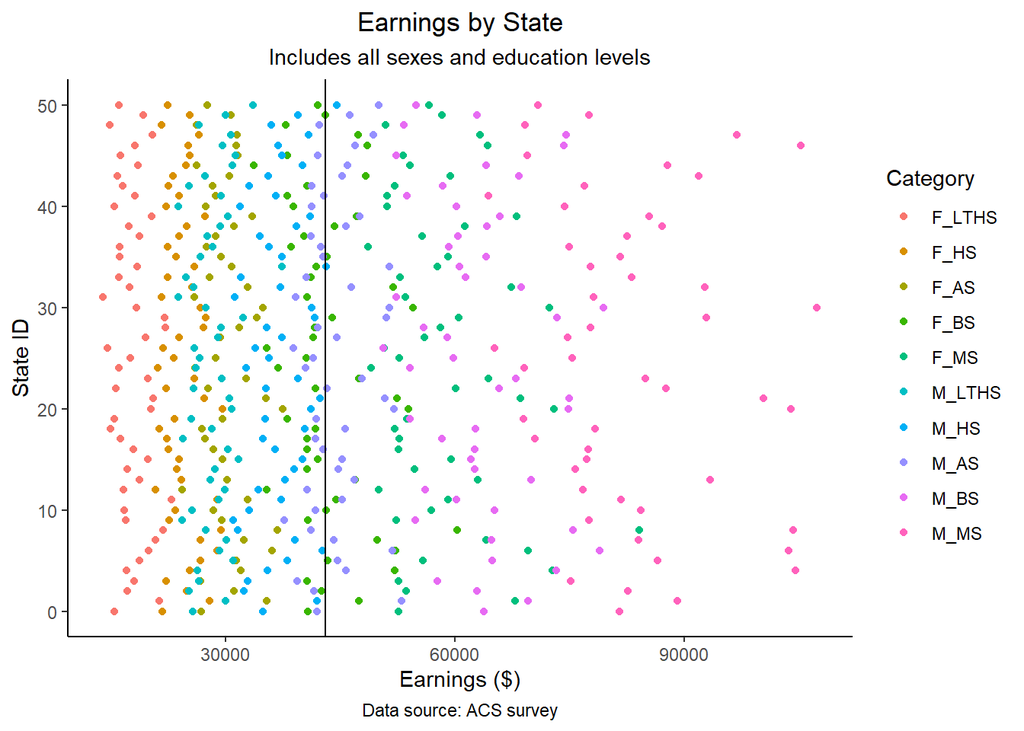

```r
ggplot(mf_stateobs[1:510,], aes(ID - 1, Observation)) + geom_point(aes(color = Category)) +
  geom_hline(yintercept = mfobs.mean$mean)+
  labs(x = "State ID",
       y = "Earnings ($)",
       title = "Earnings by State",
       subtitle = "Includes all sexes and education levels",
       caption = "Data source: ACS survey") +
  coord_flip() +
  theme_classic() +
  theme(plot.caption = element_text(hjust = 0.5),
        plot.title = element_text(hjust = 0.5),
        plot.subtitle = element_text(hjust = 0.5))
```

The solid black line displays the mean earnings of all individuals in this study while the ID is a numerical representation of the state with the District of Columbia included. The median earnings of each individuals income calculated for each state is used to produce one point on the scatterplot.

Those that are above the line have above average income and tend to have higher levels of education. Perhaps most notably in this figure, we see males and females that have less than a high school diplomas sit more closely and tightly packed together with lower earnings toward the bottom of the figure. Higher earners are more educated and spread out with greater variation in their medians for each state. Here again, the trend shows that with higher education levels, higher earnings are likely.

Another analysis of variance can determine the significance of the difference in male and female earnings of each education category by state. Using the the same scatterplot, we would look to see how well the colors of the points line up in a singular bar (with upper and lower bounds) with one another. If each state had exactly the same observed differences in earnings by education then a perfectly ordered block of a single color would show for each education level. This does not appear to occur.

We can infer from the figure that there are differences in the observations of earnings for each state. We have already noted the top 5 states with the highest wage gap and the lowest 5 states with the narrowest gap. We can use the information from that analysis to determine the difference in every state. Using the observations of both genders presented in each category of this data set, we calculate the observed differences modeled by each state.

```r
mfstobs.anova <- anova_test(mf_stateobs[1:510,], Observation ~ ID)
```

```
## Coefficient covariances computed by hccm()
```

```r
mfstobs.anova
```

```
## ANOVA Table (type II tests)
##
##   Effect DFn DFd     F     p p<.05     ges
## 1     ID   1 508 0.402 0.526       0.00079
```

Our null hypothesis of this section would be that there is no significant difference by state in the observed differences of earnings by education. Alternatively, if this hypothesis were proven incorrect, we could say that this a significant difference in the observed differences of earnings by education in the states of the United States. However, this is not the case and we fail to reject the null hypothesis.

With an F-value of 0.402 and p-value of 0.526 the results of this hypothesis test are not significant and the variation in the median earnings of each education level by state is likely due to chance.

Now we can review all states by their ID values. These values were assigned to the states in alphabetical order starting with Alabama and include the District of Columbia. The darker the shade of blue the earlier the state occurs in the alphabetical list.

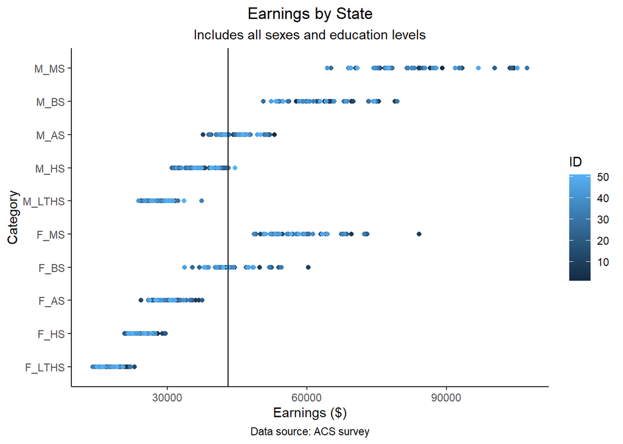

```r
ggplot(mf_stateobs[1:510,], aes(Observation, Category, color = ID)) +
  geom_point() +
  geom_vline(xintercept = mfobs.mean$mean) +
  labs(x = "Earnings ($)",
       y = "Category",
       title = "Earnings by State",
       subtitle = "Includes all sexes and education levels",
       caption = "Data source: ACS survey") +
  theme_classic() +
  theme(plot.caption = element_text(hjust = 0.5),
        plot.title = element_text(hjust = 0.5),
        plot.subtitle = element_text(hjust = 0.5))
```

Variables in the category of female start with an F, followed by the abbreviation for their education level. The same rule applies to male categories and both are concentrated on the upper and lower halves of the chart.

It appears as though there might be a cluster of slightly darker points on the right side of the data for the female education categories of *less than high school*, *high school*, and *some college or an associates degree*. However, the same does not occur for the rest of female education categories nor any male category. Additionally, there are a few darker points located on the far left sides of the data in these categories and they all seem to be randomly spread throughout as depicted in the results of the analysis of variance.

## Conclusion

Through an analysis of variance on the observed differences in wages at the educational levels of less than high school, high school, some college or associates degree, bachelors degree, masters or graduate degree, we can conclude that higher levels of education did increase the average annual earnings of males and females age 25 and older in 2018. However, we were unable to prove that results at the state level were significantly different from one another, suggesting no state has reduced its wage gap beyond that of random variation in the same year.

Results for the increase in earnings by higher education attainment were significant at the 0.0001 level with a p-value of 0 and f-value of 106.948. Higher education has a strong correlation with higher average earnings. Variations in this data is extremely unlikely to have occurred by chance.

Results for the difference in earnings by state suggest that any variation in the observed differences in wages or proportions of female to male earnings is likely to have occurred by chance. It had a p-value of 0.526 and thus is not significant at the 0.05 alpha level. The associated f-value 0.402 being very near 1 demonstrates the increased probability that there is no state with a significant difference in the wage gap.

On average across this entire study, females working full-time make $11,510 less than males per year. For females in their prime working ages of 25 to 54, this could result in a difference of $333,790 over this 29 year span if trends in observed differences held constant. For reference, the average male earns $51,477 per year and would accumulate $1,492,833 over the same working duration if variables remained constant.

For both males and females education is likely to improve their average earnings but it does not mitigate the observed differences in earnings between men and women. Instead, the observed differences (the gap) increase with higher education.

These results are unadjusted and include individuals choices of occupation, differences in experience levels, hours worked, salary negotiations, and all other variables associated with the earnings of individuals in United States. This analysis depicts a more realistic view of the gender wage gap in the United States for the year 2018 and elucidates some common misconceptions about education’s effect on the gender wage gap in the United States.

## References

Find out more about their methodology here: https://www.census.gov/programs-surveys/acs/methodology.html